# TruMedia Hackathon 2017

Christopher Teixeira

This document represents the work of Christopher Teixeira for the 2017 TruMedia Hackathon.

# Understanding pitches

For illustrative purposes, I wanted to understand this new field *probCalledStrike* to see how well it might be used to determine a pitcher’s best pitch.

```
## Observations: 726,023
## Variables: 58
## $ seasonYear              <int> 2016, 2016, 2016, 2016, 2016, 2016, 20...
## $ gameString              <chr> "gid_2016_04_03_slnmlb_pitmlb_1", "gid...
## $ gameDate                <dttm> 2016-04-03 13:05:00, 2016-04-03 13:05...
## $ gameType                <chr> "REG", "REG", "REG", "REG", "REG", "RE...
## $ visitor                 <chr> "STL", "STL", "STL", "STL", "STL", "ST...
## $ home                    <chr> "PIT", "PIT", "PIT", "PIT", "PIT", "PI...
## $ visitingTeamFinalRuns   <int> 1, 1, 1, 1, 1, 1, 1, 1, 1, 1, 1, 1, 1,...
## $ homeTeamFinalRuns       <int> 4, 4, 4, 4, 4, 4, 4, 4, 4, 4, 4, 4, 4,...
## $ inning                  <int> 1, 1, 1, 1, 1, 1, 1, 1, 1, 1, 1, 1, 1,...
## $ side                    <chr> "T", "T", "T", "T", "T", "T", "T", "T"...
## $ batterId                <int> 572761, 572761, 502054, 407812, 407812...
## $ batter                  <chr> "Matt Carpenter", "Matt Carpenter", "T...
## $ batterHand              <chr> "L", "L", "R", "R", "R", "R", "R", "R"...
```

[output cut: 45 more lines]

```r
bp <- d %>%
  filter(pitcher=="Jon Lester") %>%
  group_by(pitcher, pitchType) %>%
  summarise(numPitches= n(),
            probCalledStrikeMean = mean(probCalledStrike),
            probCalledStrikeSd = sd(probCalledStrike)) %>%
  arrange(desc(probCalledStrikeMean))

knitr::kable(bp)
```

| pitcher | pitchType | numPitches | probCalledStrikeMean | probCalledStrikeSd |
| --- | --- | --- | --- | --- |
| Jon Lester | FF | 1907 | 0.5085941 | 0.4206303 |
| Jon Lester | FC | 617 | 0.4966564 | 0.4293466 |
| Jon Lester | SI | 518 | 0.4191853 | 0.4028690 |
| Jon Lester | CH | 171 | 0.3374737 | 0.4000259 |
| Jon Lester | CU | 449 | 0.2688151 | 0.3867425 |
| Jon Lester | PO | 3 | 0.0000000 | 0.0000000 |
| Jon Lester | UN | 9 | NA | NA |

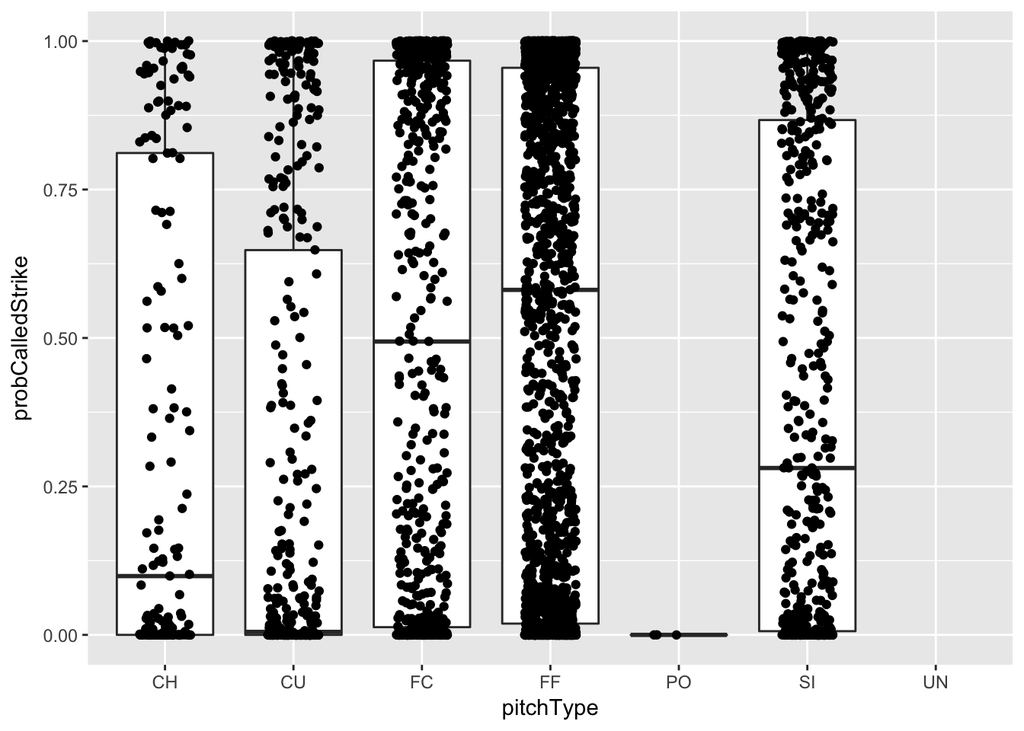

```r
library(ggplot2)
ggplot(data=d %>% filter(pitcher=="Jon Lester"),
       aes(x=pitchType,y=probCalledStrike)) +
  geom_boxplot() +
  geom_jitter(width = 0.2)
```

My next question was, “could you use *probCalledStrike* as a way to determine whether he will throw that type of pitch again?” This gets into a bit of a sophisticated solution. Using previous pitch information, we can try and see if it helps to determine whether he feels confident in throwing that pitch.

In starting to look at this, I’m taking a very few amount of features. Here’s a quick description of the features.

```r
library(dplyr)

df <- d %>%
  filter(pitchType!="UN",
         pitchType!="PO",
         pitcher=="Jon Lester") %>%
  # filter(pitcher=="Jon Lester",
         # gameString=="gid_2016_10_25_chnmlb_clemlb_1") %>%
  select(pitcher,pitchID,pitchType,probCalledStrike,pitchResult,batterHand,umpireId) %>%
  mutate(lastPitchType=lag(pitchType),
         lastprobCallStrike=lag(probCalledStrike),
         lastPitchResult = lag(pitchResult),
         lastBatterHand = lag(batterHand)) %>%
  filter(pitchID>1) %>%
  select(-pitchResult,-pitchID,-probCalledStrike,-pitcher)

df$pitchType <- factor(df$pitchType)
# df$pitcher <- factor(df$pitcher)
df$lastPitchType <- factor(df$lastPitchType)
df$lastPitchResult <- factor(df$lastPitchResult)
df$batterHand <- factor(df$batterHand)
df$lastBatterHand <- factor(df$lastBatterHand)
df$umpireId <- factor(df$umpireId)

knitr::kable(data.frame(Features=names(df),
                        Description=c("The pitch type being predicted",
                                      "The batter's hand",
                                      "The umpire making the call",
                                      "The last pitch type thrown",
                                      "The last pitch probability of called strike",
                                      "The last pitch result",
                                      "The batter's hand against the last pitch")))
```

| Features | Description |
| --- | --- |
| pitchType | The pitch type being predicted |
| batterHand | The batter’s hand |
| umpireId | The umpire making the call |
| lastPitchType | The last pitch type thrown |
| lastprobCallStrike | The last pitch probability of called strike |
| lastPitchResult | The last pitch result |
| lastBatterHand | The batter’s hand against the last pitch |